# MUM 2024-25 Problem regresji

## Zadanie regresji

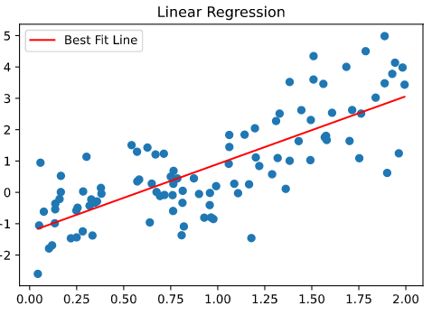

1. $y$ jest liczbą rzeczywistą
2. w kodzie to po prostu float

## Model M

1. parametry $\theta$, nauczone parametry $\widehat\theta$
2. w problemie regresji **model jest funkcją** $$M: (\mathbf{x}, \theta) \mapsto \widehat{\mathbf{p}}$$
3. można oznaczyć nauczony model $M_{\widehat\theta}$ i wtedy $$M_{\widehat\theta}: \mathbf{x} \mapsto \widehat{p}$$
4. $\widehat{p}$ to rozkład prawdopodobieństwa na $\mathbb{R}$
- jak model może zwrócić rozkład prawdopodobieństwa?
- w wypadku dyskretnym mógł zwrócić wektor długości $K$, który opisywał wszystkie prawdopodobieństwa po kolei
- tutaj musimy opisać rozkład na całej prostej

## Funkcja, która zwraca rozkład ciągły

1. **"umawiamy się"** z modelem na pewną **rodzinę rozkładów prawdopodobieństwa**
2. model **zwraca liczbę** lub **wektor liczb**
3. my traktujemy tę liczbę (wektor) jako **parametry rozkładu** z ustalonej rodziny
4. parametry rozkładu to **output** modelu, a **nie parametry** modelu!
5. przykład
- rodzina rozkładów normalnych $\mathcal{N}(\mu, 1)$ o stałej wariancji
- model zwraca $\mu\in\mathbb{R}$
- my interpretujemy liczbę $\mu$ jako rozkład $\mathcal{N}(\mu, 1)$
6. skąd model "wie", że się z nim umówiliśmy?
- model "wie", że ma zwrócić liczbę
- model "wie", że minimalizujemy funkcję kosztu
- my definiujemy funkcję kosztu - dobieramy ją tak, żeby zgadzała się z naszymi oczekiwaniami

## Maximum Likelihood w regresji - Mean Squared Error

1. model zwraca liczbę $\mu\in\mathbb{R}$
- $M_{\widehat\theta}(\mathbf{x}_n) = \mu_n$
- interpretujemy liczbę $\mu$ jako rozkład normalny $\mathcal{N}(\mu, 1)$
- możemy myśleć, że $\mu_n$ to **"prawdziwa"** etykieta dla $\mathbf{x}_n$, do której w zbiorze treningowym **dodano szum gaussowski** $\mathcal{N}(0, 1)$
2. maksymalizujemy **warunkowe** likelihood
- likelihood $y_n$ pod warunkiem $\mathbf{x}_n$
- iloczyn po wszystkich parach $(\mathbf{x}_n, y_n)$ - **założenie I.I.D.**!
- wzór na likelihood $$ \mathcal{N}(\mu_1, 1)(y_1)\cdot\ldots\cdot\mathcal{N}(\mu_N, 1)(y_N) = \prod_{n=1}^N \dfrac{1}{\sqrt{2\pi}}\exp\left(\dfrac{-(y_n-\mu_n)^2}{2}\right)$$
- negative mean log likelihood $$\ln[\sqrt{2\pi}] + \dfrac{1}{N}\sum_{n=1}^N \dfrac{(y_n-\mu_n)^2}{2} = const + \dfrac{1}{2}\dfrac{1}{N}\sum_{n=1}^N (y_n-\mu_n)^2$$
3. czyli tak naprawdę minimalizujemy $\dfrac{1}{N}\sum_{n=1}^N (y_n-\mu_n)^2$
- **błąd średniokwadratowy** (*mean squared error*)
- liczony pomiędzy wszystkimi etykietami $y_n$ a wszystkimi predykcjami $\mu_n$

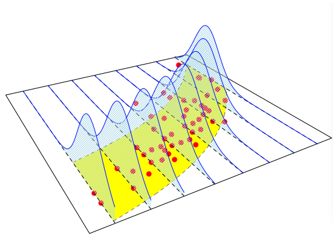

4. przypominamy model generatywny na rozkładzie normalnym
- model estymuje parametry używając
  - estymatora średniej
  - obciążonego estymatora wariancji
- jeśli zbiór treningowy ma jeden element $x$, to
  - $\widehat\mu = x, \widehat\sigma = 0$
  - ale przecież $\sigma$ musi być dodatnia!
  - "nieskończenie wąski" rozkład normalny
  - w tym wypadku w regresji nie ma tego problemu, bo ustalamy wariancję $\sigma^2 = 1$

### Wnioski

1. niech pewna wartość $\mathbf{x}$ występuje **dokładnie raz** w zbiorze treiningowym
- załóżmy, że na $n$-tej pozycji
  - $\mathbf{x}$ = $\mathbf{x}_n$
- model uczony maximum likelihood stwierdzi, że
  - $\widehat{p}(y\mid\mathbf{x}_n) = \mathcal{N}(y_n, 1)$
  - model **zapamiętuje** etykietę poprzez zapamiętanie średniej rozkładu normalnego
  - prawdziwy rozkład $p(y\mid\mathbf{x}_n)$ może być zupełnie inny, ale mamy tylko jedną parę do estymacji
2. niech pewna wartość $\mathbf{x}$ występuje **kilka razy** w zbiorze treiningowym
- jak teraz wygląda $\widehat{p}(y\mid\mathbf{x}_n)$?
  - przypomnieć sobie model generatywny
- czy to jest lepsza estymacja prawdziwego $p(y\mid\mathbf{x}_n)$?
- zazwyczaj $\mathbf{x}$ pochodzi z rozkładu ciągłego
  - żadna wartość $\mathbf{x}$ nie występuje wielokrotnie w zbiorze treningowym
3. załóżmy, że etykieta $y$ jest niezależna od $\mathbf{x}$
- model powinien się nauczyć zwracać zawsze rozkład $p(y)$
- gdyby model wiedział, że etykieta jest niezależna, to mógłby estymować $p(y)$ ze wszystkich $N$ przykładów $y_n$, nie patrząc w ogóle na $\mathbf{x}_n$
- czego nauczy się model?
4. załóżmy, że w **bliskim otoczeniu** pewnego $\mathbf{x}_n$ rozkład warunkowy $p(y\mid\mathbf{x})\simeq p(y\mid\mathbf{x}_n)$
- niech $\mathbf{x}_{n_1}, \mathbf{x}_{n_2}, \ldots, \mathbf{x}_{n_M}$ leżą w bliskim otoczeniu $\mathbf{x}_n$
- gdyby model wiedział, że rozkład $p(y\mid\mathbf{x})$ jest tu mniej więcej taki sam, to mógłby estymować go przy użyciu $M$ przykładów $y_{n_1}, \ldots, y_{n_M}$
- czego nauczy się model?
5. co jeśli źle się umówiliśmy z modelem
- prawdziwy rozkład $p(y\mid\mathbf{x_n})$ nie jest rozkładem normalnym
- czego nauczy się model, jeśli będzie myślał, że uczy się rozkładu normalnego?
  - załóżmy nawet, że ma dużo sampli $y$ dla ustalonego $\mathbf{x}$

## Inne funkcje kosztu

1. podamy jeden konkretny przykład - **Mean Absolute Error**
- minimalizujemy $\dfrac{1}{N}\sum_{n=1}^N |y_n-\mu_n|$
- to odpowiada "umowie", że model zwraca średnią **rozkładu Laplace'a**
  - wzór na gęstość $$ \dfrac{1}{2}\exp\big(-|x-\mu|\big)$$
  - czy widać, że negative mean log likelihood to, z dokładnością do stałych, mean absolute error?
2. w praktyce można zdefiniować inną "sensowną" funkcję kosztu
- "sensowna" to taka, która najlepiej rozwiązuje konkretny problem
- z reguły nie trzeba się zastanawiać, jakiemu rozkładowi ona odpowiada
- ale warto się zastanowić
- **na egzaminie obowiązkowo trzeba umieć połączyć funkcję kosztu z rozkładem prawdopodobieństwa**

## Oznaczenia

1. od tej pory będziemy mówili, że dla $\mathbf{x}_n$ model zwraca $\widehat{y_n}$
2. w zależności od funkcji kosztu $\widehat{y_n}$ może oznaczać różne rzeczy, np.
- MSE - średnia rozkładu normalnego
- MAE - średnia rozkładu Laplace'a